# Retrieve data from files

[Kotlin DataFrame library](https://kotlin.github.io/dataframe/home.html) enables you to work with both non-structured and structured data. For data transformations, you can use such methods as [`.add()`](https://kotlin.github.io/dataframe/adddf.html), [`.split()`](https://kotlin.github.io/dataframe/split.html), [`.convert()`](https://kotlin.github.io/dataframe/convert.html), and [`.parse()`](https://kotlin.github.io/dataframe/parse.html). Additionally, this toolset enables the retrieval and manipulation of data from various structured file formats, including CSV, JSON, XLS, Parquet, and Apache Arrow. See all supported formats in the [DataFrame documentation](https://kotlin.github.io/dataframe/data-sources.html).

In this guide, you can learn how to retrieve, refine, and handle data through multiple examples.

## Before you start

To follow this tutorial:

1. Select File | New | Kotlin Notebook.
2. Import Kotlin DataFrame:

   ```
   %use dataframe
   ```

   Run the code cell with the `%use dataframe` line before any other code cells to make sure the DataFrame library and its APIs are available in the notebook.

To follow the tutorial, you can also use DataFrame as a [Gradle](https://kotlin.github.io/dataframe/setupgradle.html) or [Maven](https://kotlin.github.io/dataframe/setupmaven.html) dependency.

## Retrieve data

To retrieve data from a file, use the `DataFrame.read()` function:

```
val movies = DataFrame.read("movies.csv")
```

The `DataFrame.read()` function detects the input format based on the file extension and content.

You can also pass additional arguments to control how the DataFrame library reads the input data. For example, the following code specifies a custom delimiter (`;`) for a CSV file:

```
val movies = DataFrame.read("movies.csv", delimiter = ';')
```

## Display data

Once you have the data, you can display it. The easiest way is to store your data in a variable and then return it:

```
val jsonDf = DataFrame.read("jsonFile.json")
jsonDf
```

This code displays the data from your file as an interactive table:

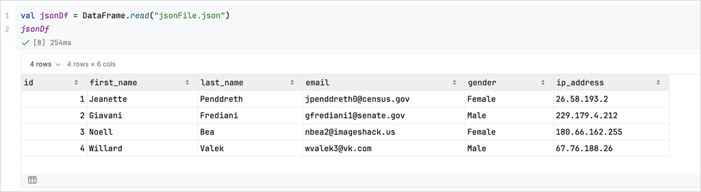

You can use this view to inspect values, check column names, and easily understand the state of your dataset.

## Inspect data structure

To gain insights into the structure or schema of your data, use the [`.schema()`](https://kotlin.github.io/dataframe/schema.html) function on your DataFrame variable.

For example, run `jsonDf.schema()` to list the type of each column in your JSON dataset:

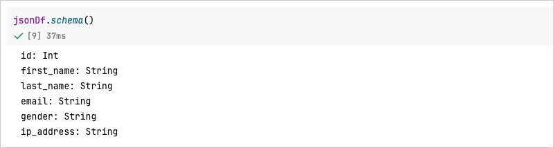

You can also use the autocompletion feature. It allows you to quickly access and manipulate the properties of your DataFrame. After loading your data, simply type the DataFrame variable followed by a period (`.`) to see a list of available columns and their types.

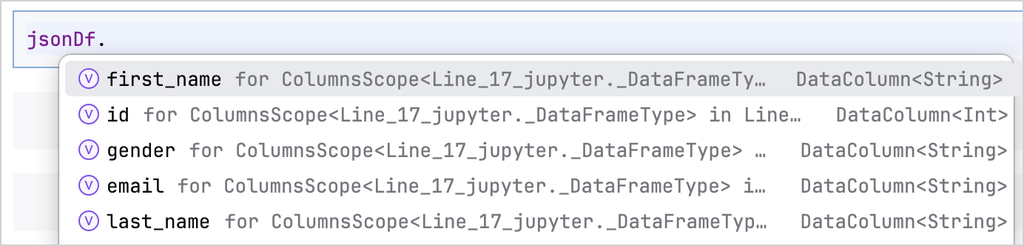

## Refine data

Kotlin DataFrame provides various operations for refining your dataset. For example, [grouping](https://kotlin.github.io/dataframe/group.html), [filtering](https://kotlin.github.io/dataframe/filter.html), [updating](https://kotlin.github.io/dataframe/update.html), or [adding new columns](https://kotlin.github.io/dataframe/add.html). These functions are essential for data analysis, allowing you to organize, clean, and transform your data effectively.

For example, let's look at the `movies.csv` dataset. It stores movie titles and release years in the same cell. The goal is to refine this dataset for easier analysis:

1. Load the data

   Load the file into a `DataFrame` using the `.read()` function:

   ```
   val movies = DataFrame.read("movies.csv")
   ```

2. Add a column

   To extract the release year from the `title` column, add a new `year` column:

   ```
   val moviesWithYear = movies
       .add("year") {
           "\\d{4}".toRegex()
               .findAll(title)
               .lastOrNull()
               ?.value
               ?.toInt()
               ?: -1
       }

   moviesWithYear
   ```

3. Update values

   To remove the release year from the movie title, update the `title` column:

   ```
   val moviesTitle = moviesWithYear
       .update("title") {
           "\\s*\\(\\d{4}\\)\\s*$".toRegex().replace(title, "")
   }

   moviesTitle
   ```

   The code keeps the movie titles in one column and moves the release years into another column.
4. Filter rows

   ```
   val newMovies = moviesTitle.filter {
       year >= 1996
   }

   newMovies
   ```

5. Remove column

   To remove a column that you do not need, use the `.remove()` function:

   ```
   val refinedMovies = newMovies.remove {
       movieID
   }

   refinedMovies
   ```

For comparison, here is the dataset before refinement:

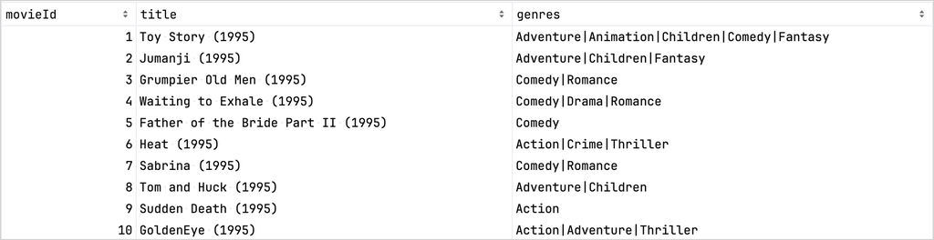

The dataset after refinement:

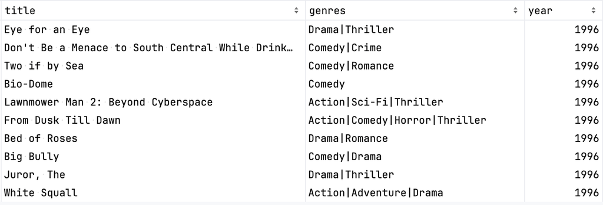

## Export data

After refining the data, you can easily export it.

You can utilize a variety of [`.write()`](https://kotlin.github.io/dataframe/write.html) functions for this purpose. It supports saving in multiple formats, including CSV, JSON, XLS, XLSX, Apache Arrow, and even HTML tables. See all supported formats in the [DataFrame documentation](https://kotlin.github.io/dataframe/data-sources.html). This can be particularly useful for sharing your findings, creating reports, or making your data available for further analysis.

For example, let's save the result as:

- JSON file using the [`.writeJson()`](https://kotlin.github.io/dataframe/write.html#writing-to-json) function:

  ```
  refinedMovies.writeJson("movies.json")
  ```

- CSV file using the [`.writeCsv()`](https://kotlin.github.io/dataframe/write.html#writing-to-csv) function:

  ```
  refinedMovies.writeCsv("movies.csv")
  ```

- [Apache Arrow files](https://kotlin.github.io/dataframe/write.html#writing-to-apache-arrow-formats) using the `.writeArrorIPC()` and `.writeArrorFeather()` functions:

  ```
  refinedMovies.writeArrowIPC("movies.arrow")
  refinedMovies.writeArrowFeather("movies.feather")
  ```

You can also open a standalone HTML table in your browser with the [`.toStandaloneHTML()`](https://kotlin.github.io/dataframe/tohtml.html) function:

```
refinedMoviesDf
    .toStandaloneHTML(DisplayConfiguration(rowsLimit = null))
    .openInBrowser()
```

## What's next

- Explore data visualization using the [Kandy library](https://kotlin.github.io/kandy/examples.html)
- Find additional information about data visualization in Data visualization with Kandy
- For an extensive overview of tools and resources available for data science and analysis in Kotlin, see Kotlin and Java libraries for data analysis